# HW5

References:

- https://keras.io/examples/generative/conditional_gan/
- https://developers.google.com/machine-learning/gan/problems ( Mode collapse)
- https://github.com/eriklindernoren/Keras-GAN/blob/master/cgan/cgan.py ( paper code)
- https://arxiv.org/abs/1701.07875

Collaborated and discussed with: Ramki, Rahul and Sushant

## GPU Check

```python
#Path: TensorFlow/Tejas/
import tensorflow as tf
device_name = tf.test.gpu_device_name()
if device_name != '/device:GPU:0':
  raise SystemError('GPU device not found')
print('Found GPU at: {}'.format(device_name))
```

```
Found GPU at: /device:GPU:0
```

```python
print("TensorFlow version:", tf.__version__)
```

```
TensorFlow version: 2.9.2
```

```python
import tensorflow as tf
import timeit

device_name = tf.test.gpu_device_name()
if device_name != '/device:GPU:0':
  print(
      '\n\nThis error most likely means that this notebook is not '
      'configured to use a GPU.  Change this in Notebook Settings via the '
      'command palette (cmd/ctrl-shift-P) or the Edit menu.\n\n')
  raise SystemError('GPU device not found')

def cpu():
  with tf.device('/cpu:0'):
    random_image_cpu = tf.random.normal((100, 100, 100, 3))
    net_cpu = tf.keras.layers.Conv2D(32, 7)(random_image_cpu)
    return tf.math.reduce_sum(net_cpu)

def gpu():
  with tf.device('/device:GPU:0'):
    random_image_gpu = tf.random.normal((100, 100, 100, 3))
    net_gpu = tf.keras.layers.Conv2D(32, 7)(random_image_gpu)
    return tf.math.reduce_sum(net_gpu)

# We run each op once to warm up; see: https://stackoverflow.com/a/45067900
cpu()
gpu()

# Run the op several times.
print('Time (s) to convolve 32x7x7x3 filter over random 100x100x100x3 images '
      '(batch x height x width x channel). Sum of ten runs.')
print('CPU (s):')
cpu_time = timeit.timeit('cpu()', number=10, setup="from __main__ import cpu")
print(cpu_time)
print('GPU (s):')
gpu_time = timeit.timeit('gpu()', number=10, setup="from __main__ import gpu")
print(gpu_time)
print('GPU speedup over CPU: {}x'.format(int(cpu_time/gpu_time)))
```

```
Time (s) to convolve 32x7x7x3 filter over random 100x100x100x3 images (batch x height x width x channel). Sum of ten runs.
CPU (s):
0.4448180969999953
GPU (s):
0.038347337999994124
GPU speedup over CPU: 11x
```

## Dependencies

```python
import numpy as np
import random
import pandas as pd
import seaborn as sns
import matplotlib.pyplot as plt
from sklearn.decomposition import PCA
from sklearn.manifold import TSNE
from tensorflow import keras
from tensorflow.keras import layers
from keras.models import Model
import keras.utils
from keras import utils as np_utils
from keras.models import Sequential
from keras.layers import  Dense, Dropout, Activation, Flatten
from librosa.core import stft,istft
import soundfile as sf
from sklearn.model_selection import train_test_split
import tensorflow as tf
import librosa
import itertools

import imageio
%matplotlib inline
```

## Load Dataset

```python
(X_train,y_train),(X_test,y_test)=keras.datasets.mnist.load_data()
```

```
Downloading data from https://storage.googleapis.com/tensorflow/tf-keras-datasets/mnist.npz
```

```python
print("X_train: ",X_train.shape)
print("X_test: ",X_test.shape)
print("y_train: ",y_train.shape)
print("y_test: ",y_test.shape)
```

```
X_train:  (60000, 28, 28)
X_test:  (10000, 28, 28)
y_train:  (60000,)
y_test:  (10000,)
```

```python
X_train = X_train.reshape(-1,784)
X_test = X_test.reshape(-1,784)
```

```python
print("X_train: ",X_train.shape)
print("X_test: ",X_test.shape)
```

```
X_train:  (60000, 784)
X_test:  (10000, 784)
```

## Scaling

```python
from sklearn.preprocessing import MinMaxScaler
```

```python
rescale=MinMaxScaler(feature_range=(-1,1))
```

```python
X_train_sc=rescale.fit_transform(X_train)
X_test_sc=rescale.fit_transform(X_test)
```

```python
print("X_train_sc: ",X_train_sc.shape)
print("X_test_sc: ",X_test_sc.shape)
```

```
X_train_sc:  (60000, 784)
X_test_sc:  (10000, 784)
```

```python
batch_size = 100
num_classes = 10
image_size = 784 #Flatten image
latent_dim = 100
middle_image= (10*10)
```

```python
y_train = keras.utils.to_categorical(y_train, num_classes)
y_test = keras.utils.to_categorical(y_test, num_classes)
```

```python
print("y_train: ",y_train.shape)
print("y_test: ",y_test.shape)
```

```
y_train:  (60000, 10)
y_test:  (10000, 10)
```

```python
all_image = np.concatenate([X_train_sc,X_test_sc])
all_image = all_image.astype('float32')
all_label = np.concatenate([y_train,y_test])
```

```python
all_image.shape
```

```
(70000, 784)
```

```python
all_label.shape
```

```
(70000, 10)
```

```python
dataset = tf.data.Dataset.from_tensor_slices((all_image, all_label))
# dataset = dataset.shuffle(buffer_size=1024).batch(batch_size)
dataset = dataset.batch(batch_size)
```

```python
print("Shape of training images: {}".format(all_image.shape))
print("Shape of training labels: {}".format(all_label.shape))
```

```
Shape of training images: (70000, 784)
Shape of training labels: (70000, 10)
```

```python
gen_input = latent_dim + middle_image
dis_input = image_size
print("Generator Input Size:",gen_input)
print("Discriminator Input Size:",dis_input)
```

```
Generator Input Size: 200
Discriminator Input Size: 784
```

## Model

Following Professors model an keeping leaky relu and tanh activations.

```python
# Following Profssors Model.
discriminator = keras.Sequential(
    [
        keras.layers.InputLayer((dis_input,)),
        layers.Dense(400,kernel_initializer = tf.keras.initializers.HeNormal(), activation = tf.nn.leaky_relu),
        layers.Dense(200,kernel_initializer = tf.keras.initializers.HeNormal(), activation = tf.nn.leaky_relu),
        layers.Dense(100,kernel_initializer = tf.keras.initializers.HeNormal(), activation = tf.nn.leaky_relu),
        layers.Dense(1,kernel_initializer = tf.keras.initializers.HeNormal())
    ],
    name="discriminator",
)

# Create the generator.
generator = keras.Sequential(
    [
        keras.layers.InputLayer((gen_input,)),
        layers.Dense(200,kernel_initializer = tf.keras.initializers.HeNormal()),
        layers.BatchNormalization(momentum=0.5),
        layers.Dense(400,kernel_initializer = tf.keras.initializers.HeNormal()),
        layers.BatchNormalization(momentum=0.5),
        layers.Dense(784,kernel_initializer = tf.keras.initializers.HeNormal(),activation='tanh')
    ],
    name="generator",
)
```

```python
discriminator.summary()
```

```
Model: "discriminator"
_________________________________________________________________
 Layer (type)                Output Shape              Param #
=================================================================
 dense_7 (Dense)             (None, 400)               314000

 dense_8 (Dense)             (None, 200)               80200

 dense_9 (Dense)             (None, 100)               20100

 dense_10 (Dense)            (None, 1)                 101

=================================================================
Total params: 414,401
Trainable params: 414,401
Non-trainable params: 0
_________________________________________________________________
```

```python
generator.summary()
```

```
Model: "generator"
_________________________________________________________________
 Layer (type)                Output Shape              Param #
=================================================================
 dense_11 (Dense)            (None, 200)               40200

 batch_normalization_2 (Batc  (None, 200)              800
 hNormalization)

 dense_12 (Dense)            (None, 400)               80400

 batch_normalization_3 (Batc  (None, 400)              1600
 hNormalization)

 dense_13 (Dense)            (None, 784)               314384

=================================================================
Total params: 437,384
Trainable params: 436,184
Non-trainable params: 1,200
_________________________________________________________________
```

USED AND MODIFIED KERAS VERSION (https://keras.io/examples/generative/conditional_gan/)

**TRY 1:** I even saw the implementation of these guys who published a paper on wesserstein loss for mode collapse they use similar structures. they multiplied discriminator loss by 0.5. I saw seperation in accuracies, and all outputs were 7,1 or 9.

**TRY2:** Tried changing labels from 0 to 1 and 1 to 0 but that didnt work. So error was not ijn how labels go in. Notes about the Function Below:

**TRY 3:** This time outputs were 3,6 so issue is with discriminator settings.

**TRY 4:** Removed datashuffling, just batched the data This time outputs were 3,8 mostly 3 so issue is with discriminator settings.

Def middle_patch :

def metrics:

- Uses the same way keras tracks all metrics for history, its like a repo of all things to be tracked

def init:

- Initializes all these variables on call

In discriminator we are passing random norm dist as fake image and also the real image.

In Generator we are passing random norm dist as fake image and also the middle image ( output of def middle_patch ) .

```python
class Cond_GAN(keras.Model):
    def __init__(self, discriminator, generator, latent_dim):
        super(Cond_GAN, self).__init__()
        self.discriminator = discriminator
        self.generator = generator
        self.latent_dim = latent_dim
        self.gen_loss_tracker = keras.metrics.Mean(name="generator_loss")
        self.disc_loss_tracker = keras.metrics.Mean(name="discriminator_loss")
        self.real_acc_tracker = tf.keras.metrics.BinaryAccuracy(name="real_acc")
        self.fake_acc_tracker = tf.keras.metrics.BinaryAccuracy(name="fake_acc")

    def middle_patch(self,data):
    #See Notes above
    #This function calculates patches,10:20 is right 10:19 takes only 9 patches and that gave dimension issue
    #Since out dataset if of type tensorflow batch, it naturally feeds input in batches of 100, but images are passsed 1 by 1
    #Output is a batch though, so if you uncomment my print and run it you will see it run 100 times for every call.
        real_images, one_hot_labels = data
        #image_data = real_images.reshape(-1,28,28)
        image_data = tf.reshape(real_images,shape=(-1,28,28))
        #print(image_data.shape)
        middle_images = image_data[:,10:20,10:20]
        #print(middle_images.shape)
        #new_images = middle_images.reshape(-1,10*10)
        new_images = tf.reshape(middle_images,shape=(-1,10*10))
        #print(new_images.shape)

        return new_images

    @property
    def metrics(self):
        return [self.gen_loss_tracker, self.disc_loss_tracker,self.real_acc_tracker,self.fake_acc_tracker]

    def compile(self, d_optimizer, g_optimizer, loss_fn):
        super(Cond_GAN, self).compile()
        self.d_optimizer = d_optimizer
        self.g_optimizer = g_optimizer
        self.loss_fn = loss_fn

    def train_step(self, data):
        real_images, one_hot_labels = data
        #print(real_images.shape)
        new_images = self.middle_patch(data)
        #image_data = real_images.reshape(-1,28,28)
        # image_data = tf.reshape(real_images,shape=(-1,28,28))
        # print(image_data.shape)
        # middle_images = image_data[:,10:19,10:19]
        # #new_images = middle_images.reshape(-1,10*10)
        # new_images = tf.reshape(middle_images,shape=(-1,10*10))
        # print(new_images.shape)
        # print('ccccc')

        #one_hot_labels = tf.cast(one_hot_labels, tf.float32)

        batch_size = tf.shape(real_images)[0]
        random_latent_vectors = tf.random.normal(shape=(batch_size, self.latent_dim))
        random_vector_labels = tf.concat([random_latent_vectors, new_images], axis=1)

        generated_images = self.generator(random_vector_labels)

        fake_image_and_labels = generated_images
        real_image_and_labels = real_images
        combined_images = tf.concat([fake_image_and_labels, real_image_and_labels], axis=0)

        labels = tf.concat([tf.ones((batch_size, 1)), tf.zeros((batch_size, 1))], axis=0)
        with tf.GradientTape() as tape:
            predictions = self.discriminator(combined_images)
            d_loss = self.loss_fn(labels, predictions)
        grads = tape.gradient(d_loss, self.discriminator.trainable_weights)
        self.d_optimizer.apply_gradients(zip(grads, self.discriminator.trainable_weights))

        self.fake_acc_tracker.update_state(labels[:batch_size,:],predictions[:batch_size,:])
        self.real_acc_tracker.update_state(labels[batch_size:,:],predictions[batch_size:,:])

        # new_images = self.middle_patch(data)

        # image_data = real_images.reshape(-1,28,28)
        # middle_images = image_data[:,10:19,10:19]
        # new_images = middle_images.reshape(-1,10*10)

        random_latent_vectors = tf.random.normal(shape=(batch_size, self.latent_dim))
        #print(random_latent_vectors.shape)
        random_vector_labels = tf.concat([random_latent_vectors, new_images], axis=1)
        #print(random_vector_labels.shape)
        misleading_labels = tf.zeros((batch_size, 1))



        with tf.GradientTape() as tape:
            fake_images = self.generator(random_vector_labels)
            #fake_image_and_labels = tf.concat([fake_images, new_images], -1)
            predictions1 = self.discriminator(fake_images)
            g_loss = self.loss_fn(misleading_labels, predictions1)
            #g_loss = 0.5*g_loss
        grads = tape.gradient(g_loss, self.generator.trainable_weights)
        self.g_optimizer.apply_gradients(zip(grads, self.generator.trainable_weights))

        self.gen_loss_tracker.update_state(g_loss)
        self.disc_loss_tracker.update_state(d_loss)
        return {
            "g_loss": self.gen_loss_tracker.result(),
            "d_loss": self.disc_loss_tracker.result(),
            "real_acc": self.real_acc_tracker.result(),
            "fake_acc": self.fake_acc_tracker.result()
        }
```

```python
#type(dataset)
```

```python
cond_gan = Cond_GAN(
    discriminator=discriminator, generator=generator, latent_dim=latent_dim
)
cond_gan.compile(
    d_optimizer=keras.optimizers.Adam(learning_rate=0.0003),
    g_optimizer=keras.optimizers.Adam(learning_rate=0.0003),
    loss_fn=keras.losses.BinaryCrossentropy(from_logits=True),
)

history = cond_gan.fit(dataset, epochs=100)
```

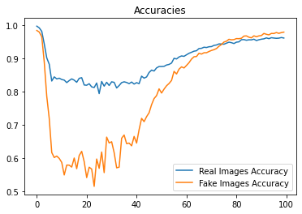

```python
plt.plot(history.history['real_acc'],label='Real Images Accuracy')
plt.plot(history.history['fake_acc'],label='Fake Images Accuracy' )
plt.legend(loc="best")
plt.title("Accuracies")
```

```python
# noise = np.random.normal(0,1,(100, latent_dim))

# labels=[]
# for x in np.eye(10):
#   for i in range(10):
#     labels.append(x.tolist())
# labels = np.array(labels)

# image = cond_gan.generator.predict(np.concatenate([noise,labels],axis=1))
# image = 0.5 * image + 0.5
# fig, ax = plt.subplots(10,10, figsize = (10,10))
# cnt = 0
# for i in range(10):
#     for j in range(10):
#         ax[i,j].imshow(image[cnt,:].reshape((28,28)))
#         ax[i,j].axis('off')
#         cnt+=1
# plt.show()
```

```python
(X_train,y_train),(X_test,y_test)=keras.datasets.mnist.load_data()
```

```
Generated Images
(100, 100)
```

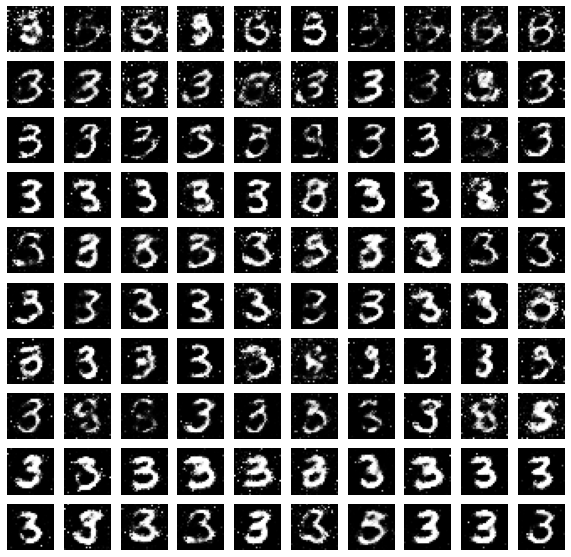

```python
print("Generated Images")
noise = np.random.normal(0,1,(10*10, 100))
data_index = np.zeros((100,28,28))
ten_index = []
# for i in range(0,10):
#   index = np.where(y_test == i)
#   #print(index[:10])
#   print(i)
#   for i in range(10):
#     ten_index.append(index[0][i])
#   #print(type(ten_index))
#   print(ten_index)
#   #data_index.append(ten_index.item())

# for i in range(10):
#   for j in range(10):
#     data_index[i*10+j] = X_test_sc[ten_index[i*10+j]]

result = []
for i in range(10):
    result.append(np.array(np.where(y_test == i)[0][:10]))
final_array = np.concatenate(result, axis=0)

mean_patch = tf.reshape(X_test_sc[final_array],shape=[-1,28,28])[:,10:20,10:20]
mean_patch = tf.reshape(mean_patch,[mean_patch.shape[0], -1])

#noise.shape
print(mean_patch.shape)

gen_image = cond_gan.generator.predict(np.concatenate([noise,mean_patch],axis=1))
gen_image = 0.5 * gen_image + 0.5

gen_image = tf.reshape(gen_image,shape=[-1,28,28])

fig, ax = plt.subplots(10,10, figsize = (10,10))
cnt = 0
for i in range(10):
    for j in range(10):
      #gen_image= tf.reshape(gen_image[cnt,:],shape=(28,28))
      ax[i,j].imshow(gen_image[cnt,:],cmap = 'gray')
      ax[i,j].axis('off')
      cnt+=1
plt.show()
```

Facing Mode Collapse issue : https://developers.google.com/machine-learning/gan/problems

apparently its a issue of repeated output of just a small set of datapoints.

```python
%%shell
jupyter nbconvert --to html /content/Deep_Learning_HW5_Q4-2.ipynb
```

```
[NbConvertApp] Converting notebook /content/Deep_Learning_HW5_Q4-2.ipynb to html
[NbConvertApp] Writing 722560 bytes to /content/Deep_Learning_HW5_Q4-2.html
```